# Estimating Periodontitis Susceptibility Cases for Epidemiological Studies with Multiple Imputation

Lujun Zhang, Mengli Xiao, Haitao Chu, Georgios A. Kotsakis, Weihua Guan

2023-10-19

This file contains code for reproducing results and figures for the paper: Estimating Periodontitis Susceptibility Cases for Epidemiological Studies with Multiple Imputation.

# 1 Set-ups

```r
set.seed(12345678)
FIG.WIDTH = 8
RECYCLE = FALSE
library(Hmisc)
library(tidyverse)
# library(glmnet)
# library(e1071)
library(kableExtra)
# library(ROCR)
library(ggconsort)
library(ggpattern)
sum.na <- function(x) sum(x,na.rm=T)
NA_num <- function(x) sum(is.na(x))
carry_over_missing_sites <- function(x){
  if(sum(!is.na(x)) == 0) return(x) else{
    length.na <- length(x[is.na(x)])
    x[is.na(x)] <- sample(x[!is.na(x)], replace = TRUE, size = length.na)
    return(x)
  }
}
case_definition <- function(d){
  sum.na <- function(x){sum(x,na.rm=T)}

  #only the pc and la columns
  num.teeth <- names(d) %>% str_subset("^ohx\\d\\d") %>%
    str_extract("\\d\\d") %>% unique() %>% length
  pc <- d %>% select(contains("pc"))
  if(ncol(pc) != num.teeth*4)
    stop("Number of pc measurement != 4*number of teeth")
  la <- d %>% select(contains("la"))
  if(ncol(la) != num.teeth*4)
    stop("Number of la measurement != 4*number of teeth")

  # No
  ps <- rep("no", length = nrow(d))

  # Mild
  al.g3 <- la >= 3
  out <- 0
  for (i in 1:num.teeth){
    temp <- apply(al.g3[,(4*i-3):(4*i)], 1, sum.na) > 0
    out <- temp + out
  }
  mild.al <- out >= 2

  pc.g4 <- pc >= 4
  out <- 0
  for (i in 1:num.teeth){
    temp <- apply(pc.g4[,(4*i-3):(4*i)], 1, sum.na) > 0
    out <- temp + out
  }
  mild.pc4 <- out >= 2

  pc.g5 <- pc >= 5
  mild.pc5 <- apply(pc.g5, 1, sum.na) > 0

  # d$ps[((mild.pc4 * mild.al)+mild.pc5)>0] <- "mild"
  ps[(((mild.pc4 +mild.pc5)>0)*mild.al)>0] <- "mild"

  # Moderate
  al.g4 <- la >= 4
  out <- 0
  for (i in 1:num.teeth){
    temp <- apply(al.g4[,(4*i-3):(4*i)], 1, sum.na) > 0
    out <- temp + out
  }
  moderate.al <- out >= 2

  pc.g5 <- pc >= 5
  out <- 0
  for (i in 1:num.teeth){
    temp <- apply(pc.g5[,(4*i-3):(4*i)], 1, sum.na) > 0
    out <- temp + out
  }
  moderate.pc <- out >= 2

  ps[(moderate.pc+moderate.al) > 0] <- "mod"

  # Severer
  al.g6 <- la >= 6
  out <- 0
  for (i in 1:num.teeth){
    temp <- apply(al.g6[,(4*i-3):(4*i)], 1, sum.na) > 0
    out <- temp + out
  }
  severer.al <- out >= 2

  pc.g5 <- pc >= 5
  severer.pc5 <- apply(pc.g5, 1, sum.na) > 0

  ps[(severer.al*severer.pc5)>0] <- "sev"
  S <- ps=="sev"
  MS <- ps=="sev" | ps=="mod"
  d <- d %>% mutate(ps = ps, S = S, MS = MS)
  return(d)
}

calculate_metrics <- function(data = c("Original","With MICE"),
                  method = c("Full Mouth", "naive Ramfjord", "SVM (Full Mouth)", "SVM (Ramfjord Teeth)"),
                  case = c("Severe", "Moderate-Severe"),
                  test.d_miced = test.d_miced, test.d_orgin = test.d_orgin,
                  train.d_miced = train.d_miced, train.d_orgin = train.d_orgin,
                  Ramfjord = Ramfjord, Full_mouth = Full_mouth,
                  digit = 1){
  if(data == "Original") {
    train <- train.d_orgin
    test <- test.d_orgin
  }else if(data == "With MICE"){
    train <- train.d_miced
    test <- test.d_miced
  }


  if(case == "Severe") {
    VAR = "S"
  }else if(case == "Moderate-Severe"){
    VAR = "MS"
  }
  true_value = pull(test, VAR) %>% as.numeric() #1/0

  flag_fixed <- NA
  if(method == "Full Mouth") {
    pred_value <- true_value %>% as.numeric()
    flag_fixed <- TRUE
  } else if(method == "naive Ramfjord"){
    pred_value <- test %>% select(all_of(Ramfjord)) %>% case_definition() %>%
      pull(VAR) %>% as.numeric()
    flag_fixed <- TRUE
  } else if(method == "SVM (Ramfjord Teeth)"){
    # how to deal with the missing values when it comes to SVM???
    index <- which(names(train) %in% Full_mouth)
    for(i in index) {train[[i]] <- replace_na(train[[i]], 0); test[[i]] <- replace_na(test[[i]], 0)}
    model <- train %>% mutate(S = as.numeric(S), MS = as.numeric(MS)) %>%
      svm(formula = as.formula(
        paste(VAR, "~", paste(Ramfjord,collapse="+"), collapse= "")),data= .)
    pred_value <- predict(model, type="response", newdata=test)
    flag_fixed <- FALSE
  } else if(method == "SVM (Full Mouth)"){
    index <- which(names(train) %in% Full_mouth)
    for(i in index) {train[[i]] <- replace_na(train[[i]], 0); test[[i]] <- replace_na(test[[i]], 0)}
    model <- train %>% mutate(S = as.numeric(S), MS = as.numeric(MS)) %>%
      svm(formula = as.formula(
            paste(VAR, "~", paste(Full_mouth,collapse="+"), collapse= "")),data= .)
    pred_value <- predict(model, type="response", newdata=test)
    flag_fixed <- FALSE
  }

  # metric = c("Prevalence", "AUC", "Sensitivity", "Specificity", "F1-score",
  #                            "Diagnostic Odds Ratio")

  if(flag_fixed){
    temp <- table(predictions = pred_value, true = true_value)
    TN = temp[1,1]
    FP = temp[2,1]
    TP = temp[2,2]
    FN = temp[1,2]
  } else if(!flag_fixed){
    for(threshold in 0:100){
      pred_value_temp <- as.numeric(pred_value >= threshold/100)
      temp <- table(predictions = pred_value_temp, true = true_value)
      TN = temp[1,1]
      FP = temp[2,1]
      TP = temp[2,2]
      FN = temp[1,2]
      Specificity = TN/(TN+FP)
      if(Specificity >= 0.95) break
    }
  }

  metrics = c("Prevalence", "AUC", "Sensitivity", "Specificity", "F1-score", "Diagnostic Odds Ratio")
  metric = rep(NA, length=length(metrics))
  names(metric) <- metrics
  metric["Prevalence"] <- (TP+FP)/(TP+TN+FP+FN)
  metric["Sensitivity"] <- TP/(TP+FN)
  metric["Specificity"] <- TN/(TN+FP)
  metric["F1-score"] <- 2*TP/(2*TP+FP+FN)
  metric["Diagnostic Odds Ratio"] <- (TP/FN)/(FP/TN)
  if(flag_fixed) metric["AUC"] <- NA else if(!flag_fixed){
    perf <- prediction(predictions = pred_value, labels = true_value) %>% performance(., "auc")
    metric["AUC"] <- perf@y.values[[1]]
  }
  return(metric)
}

#color map:
COLORS = c(hsv(h=336/360, s = 1, v = 0.85), hsv(h=189/360, s = 1, v = 0.85),
           hsv(h=336/360, s = 1, v = 0.5), hsv(h=189/360, s = 1, v = 0.5),
           hsv(h=336/360, s = 1, v = 0.2), hsv(h=189/360, s = 1, v = 0.2))
```

# 2 Data input part:

Definition of covariates：

- ohq835: integer, Do you think you might have gum disease?
- ohq850: integer, Ever had treatment for gum disease?
- ohq855: integer, Any teeth became loose without an injury
- ohq860: integer, Ever been told of bone loss around teeth
- smk_stt: bollean, derived from `smq020` and `smq 040`
  - If `SMQ020` AND `SMQ040` are both positive then YES, if else NO.
  - `smq020`: {1,2,NA} “Smoked at least 100 cigarettes in life”
  - `smq040`: {1,2,3,NA} “Do you now smoke cigarettes”

Datasets:

- `DATA`: dental health examination data
- `demo`: demographic data
- `Q4` and `Q5`: four question variables and `smk_stt`
- `data`: metged dataset

Case definition in the original dataset:

- Create the periodontal disease classification variable `sp`
- Separate variables into probing and attachment measures
- Input:
  - the dataset includes No. 02-31 teeth and each tooth has `la` and `pc` measurements.
  - NAs were consider **negative**
- Outcomes:
  - `d$ps`: indicator for periodontal disease, values “mild”, “mod”, “sev”
  - `d$S`: indicator for *severe* periodontal disease, values TRUE/FALSE
  - `d$MS`: indicator for *moderate* to *severe* periodontal diseases, values TRUE/FALSE

```r
DATA <- read.csv("perio_NHANES.csv")
demo <- read.csv("nhanes_demo.csv")
temp1 <- merge(DATA, demo, all=F, by.x="seqn", by.y= "SEQN")

covariates <- c("seqn", "ohq835", "ohq850", "ohq855", "ohq860")

#Check if the data given by George is the one where no-tooth participants are filtered.
DATA.F <- haven::read_xpt("OHXPER_F.xpt")
DATA.G <- haven::read_xpt("OHXPER_G.xpt")
if(identical(names(DATA.F), names(DATA.G)))
  DATA.raw <- bind_rows(DATA.F, DATA.G) else
    stop("variable names of DATA.F and DATA.G do not match")
names(DATA.raw) <- tolower(names(DATA.raw))
DATA.processed <- DATA.raw %>%
  select("seqn", matches("[(pc)(la)][dspa]$"))
for(i in 2:length(DATA.processed))
  DATA.processed[[i]] <- na_if(DATA.processed[[i]], 99)
teeth.processed <- DATA.processed %>%
  select( starts_with("ohx") | starts_with("seqn")) %>%
  pivot_longer(cols = starts_with("ohx"),
               names_to = "tooth_id",
               values_to = "value") %>%
  mutate(tooth = str_extract(tooth_id, "\\d\\d"),
         test = str_extract(tooth_id, "pc|la"),
         site = str_extract(tooth_id, "[d|s|p|a]$"))
num_missing_tooth.processed <- teeth.processed %>%
  group_by(seqn, tooth, test) %>%
  summarise(NA_num = NA_num(value)) %>%
  ungroup() %>%
  filter(NA_num == 4) %>%
  group_by(seqn, test) %>%
  summarise(num_missing_tooth = n()) %>%
  ungroup() %>%
  filter(test == "la") %>% select(-test)#num_missing_tooth.la == num_missing_tooth.pc
DATA.processed <- DATA.processed %>%
  left_join(x = ., y = num_missing_tooth.processed, by = "seqn") %>%
  replace_na(list(num_missing_tooth = 0))
temp <- DATA.processed %>% filter(!(seqn %in% DATA$seqn)) %>% pull(num_missing_tooth) %>% unique()
if(temp != 28) stop("The excluded participants are not only those having not teeth!")
temp <- DATA.processed %>% filter(num_missing_tooth == 28) %>% nrow()
if(temp != nrow(DATA.processed) - nrow(DATA))
  stop("the number of no-tooth participants does not equal to the difference between the two DATA")

try.F <- sasxport.get("OHQ_F.xpt")
```

```
## Processing SAS dataset OHQ_F      ..
```

```r
Q4.F <- try.F[,c("seqn", "ohq835", "ohq850", "ohq855", "ohq860")]
try.G <- sasxport.get("OHQ_G.xpt")
```

```
## Processing SAS dataset OHQ_G      ..
```

```r
Q4.G <- try.G[,c("seqn", "ohq835", "ohq850", "ohq855", "ohq860")]
# Q4 <- bind_rows(Q4.F,Q4.G)
Q4 <- bind_rows(Q4.F,Q4.G) %>%
  filter(!is.na(ohq835) & !is.na(ohq850) & !is.na(ohq855) & !is.na(ohq860))

SMK.F <- sasxport.get("SMQ_F.XPT")
```

```
## Processing SAS dataset SMQ_F      ..
```

```r
SMK.G <- sasxport.get("SMQ_G.XPT")
```

```
## Processing SAS dataset SMQ_G      ..
```

```r
# SMK.H <- sasxport.get("SMQ_H.XPT")
bind_rows(
  SMK.F %>% select(seqn, smq020, smq040) %>% mutate(source = "F"),
  SMK.G %>% select(seqn, smq020, smq040) %>% mutate(source = "G")
) %>% mutate(smk_stt = !(is.na(smq020) | is.na(smq040))) %>%
  select(seqn, smk_stt, source) -> SMK

Q5 <- inner_join(Q4, SMK, by = "seqn")
data <- merge(temp1, Q5, by.x = "seqn", by.y = "seqn", all = FALSE)

teeth <- data %>% select( starts_with("ohx") | starts_with("seqn")) %>%
  pivot_longer(cols = starts_with("ohx"),
               names_to = "tooth_id",
               values_to = "value") %>%
  mutate(tooth = str_extract(tooth_id, "\\d\\d"),
         test = str_extract(tooth_id, "pc|la"),
         site = str_extract(tooth_id, "[d|s|p|a]$"))
num_missing_tooth <- teeth %>%
  group_by(seqn, tooth, test) %>%
  summarise(NA_num = NA_num(value)) %>%
  ungroup() %>%
  filter(NA_num == 4) %>%
  group_by(seqn, test) %>%
  summarise(num_missing_tooth = n()) %>%
  ungroup() %>%
  filter(test == "la") %>% select(-test)#num_missing_tooth.la == num_missing_tooth.pc
num_missing_sites <- teeth %>%
  group_by(seqn, test) %>%
  summarise(num_missing_sites = NA_num(value)) %>%
  ungroup() %>%
  filter(test == "la") %>% select(-test)
data <- data %>%
  left_join(x = ., y = num_missing_tooth, by = "seqn") %>%
  replace_na(list(num_missing_tooth = 0)) %>%
  left_join(x = ., y = num_missing_sites, by = "seqn")
d_orgin <- data %>% case_definition

dput(data, file = "HPC//100%_sample.d")

if(RECYCLE) rm(list = c("teeth"))
```

# 3 Descriptive statistics

- CONSORT diagram

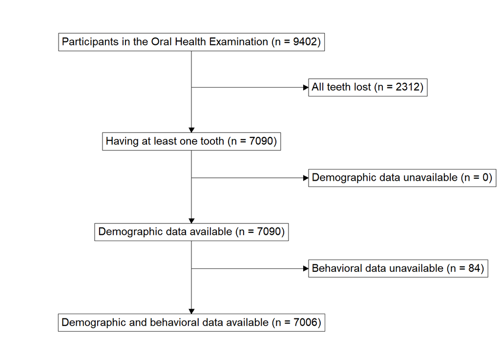

```r
study_cohorts <-
  DATA.processed %>%
  cohort_start("Participants in the Oral Health Examination") %>%
  # Define cohorts using named expressions --------------------
  # Notice that you can use previously defined cohorts in subsequent steps
  cohort_define(
    with_tooth = .full %>% filter(seqn %in% DATA$seqn),
    with_demo = with_tooth %>% filter(seqn %in% demo$SEQN),
    with_demo_Q5 = with_demo %>% filter(seqn %in% data$seqn),
    cohort_F = with_demo_Q5 %>% filter(seqn %in% SMK.F$seqn),
    cohort_G = with_demo_Q5 %>% filter(seqn %in% SMK.G$seqn),
    # anti_join is useful for counting exclusions -------------
    excluded_with_tooth = anti_join(.full, with_tooth, by = "seqn"),
    excluded_with_demo = anti_join(with_tooth, with_demo, by = "seqn"),
    excluded_with_demo_Q5 = anti_join(with_demo, with_demo_Q5, by = "seqn")
  ) %>%
  # Provide text labels for cohorts ---------------------------
  cohort_label(
    with_tooth = "Having at least one tooth",
    with_demo = "Demographic data available",
    with_demo_Q5 = "Demographic and behavioral data available",
    cohort_F = "Cohort F, the training set",
    cohort_G = "Cohort G, the test set",
    excluded_with_tooth = "All teeth lost",
    excluded_with_demo = "Demographic data unavailable",
    excluded_with_demo_Q5 = "Behavioral data unavailable"
  )

study_consort <- study_cohorts %>%
  consort_box_add(
    "full", 0, 50, cohort_count_adorn(study_cohorts, .full)) %>%
  consort_box_add(
    "excluded_with_tooth", 1, 45, cohort_count_adorn(study_cohorts, excluded_with_tooth)) %>%
  consort_box_add(
    "with_tooth", 0, 40, cohort_count_adorn(study_cohorts, with_tooth)) %>%
  consort_box_add(
    "excluded_with_demo", 1, 35, cohort_count_adorn(study_cohorts, excluded_with_demo)) %>%
  consort_box_add(
    "with_demo", 0, 30, cohort_count_adorn(study_cohorts, with_demo)) %>%
  consort_box_add(
    "excluded_with_demo_Q5", 1, 25, cohort_count_adorn(study_cohorts, excluded_with_demo_Q5)) %>%
  consort_box_add(
    "with_demo_Q5", 0, 20, cohort_count_adorn(study_cohorts, with_demo_Q5)) %>%
  # consort_box_add(
  #   "cohort_F", -30, 35, cohort_count_adorn(study_cohorts, cohort_F)) %>%
  # consort_box_add(
  #   "cohort_G", 30, 35, cohort_count_adorn(study_cohorts, cohort_G)) %>%
  consort_arrow_add(end = "excluded_with_tooth", end_side = "left", start_x = 0, start_y = 45) %>%
  consort_arrow_add("full", "bottom", "with_tooth", "top") %>%
  consort_arrow_add(end = "excluded_with_demo", end_side = "left", start_x = 0, start_y = 35) %>%
  consort_arrow_add("with_tooth", "bottom", "with_demo", "top") %>%
  consort_arrow_add("with_demo", "bottom", "with_demo_Q5", "top") %>%
  consort_arrow_add(end = "excluded_with_demo_Q5", end_side = "left", start_x = 0, start_y = 25) %>%
  # consort_arrow_add(end = "excluded_with_demo_Q5", end_side = "left", start_x = 0, start_y = 45) %>%
  consort_arrow_add("full", "bottom", "with_demo_Q5", "top") #%>%
  # consort_arrow_add("with_demo_Q5", "bottom", "cohort_F", "top") %>%
  # consort_arrow_add("with_demo_Q5", "bottom", "cohort_G", "top")

fig.temp <- study_consort %>%
  ggplot() +
  geom_consort() + xlim(-1, 2) + ylim(20, 50) +
  theme_consort(margin_h = 4, margin_v = 2) #+

fig.temp
```

```r
ggsave("figures//CONSORT.jpeg", fig.temp,
       width = FIG.WIDTH, height = 0.5*FIG.WIDTH, dpi = 1000)
ggsave("figures//CONSORT.pdf", fig.temp,
       width = FIG.WIDTH, height = 0.5*FIG.WIDTH)
if(RECYCLE) rm(list = c("Q4", "Q5", "temp1", "DATA", "demo", "fig.temp", "Q4.F", "Q4.G",
                        "SMK", "SMK.F", "SMK.G", "study_cohorts", "try.F","try.G", "study_consort"))
```

- number of subjects with different number of missing tooth

```r
tbl.temp <- d_orgin %>%
  mutate(num.miss.tooth.level = cut(num_missing_tooth,
                                    breaks = c(-Inf, 0.1, 5.1, 10.1, 15.1, Inf),
                                    labels = c("No missing","Missing <= 5",
                                               "5 < Missing <= 10",
                                               "10 < Missing <= 15",
                                               "Missing > 15"))) %>%
  mutate(ps = if_else(ps == "no", "No/Mild",
                      if_else(ps == "mod", "Moderate",
                              if_else(ps == "mild", "No/Mild", "Severe")))) %>%
  mutate(ps = factor(ps, levels = c("No/Mild", "Moderate", "Severe"))) %>%
  mutate(race = str_to_title(race)) %>%
  rename(Age = age, Sex = sex, Race = race, `Smoking Status` = smk_stt,
         `Periodontitis` = ps, `Number of Missing Teeth` = num.miss.tooth.level) %>%
  tableone::CreateTableOne(data = .,
                           vars = c("Age","Sex","Race", "Smoking Status",
                                    "Number of Missing Teeth"),
                           test = FALSE, strata = "Periodontitis",
                           addOverall = T) %>%
  tableone::kableone(., nonnormal = "Age", minMax = TRUE) %>%
  kable_classic(full_width = F, html_font = "Cambria")
tbl.temp
```

|  | Overall | No/Mild | Moderate | Severe |
| --- | --- | --- | --- | --- |
| n | 7006 | 3612 | 2527 | 867 |
| Age (median [range]) | 51.00 [30.00, 80.00] | 44.00 [30.00, 80.00] | 57.00 [30.00, 80.00] | 56.00 [30.00, 80.00] |
| Sex = male (%) | 3491 (49.8) | 1487 (41.2) | 1377 (54.5) | 627 (72.3) |
| Race (%) |  |  |  |  |
| Black | 1505 (21.5) | 644 (17.8) | 603 (23.9) | 258 (29.8) |
| Hispanic | 1745 (24.9) | 812 (22.5) | 675 (26.7) | 258 (29.8) |
| Other | 758 (10.8) | 382 (10.6) | 268 (10.6) | 108 (12.5) |
| White | 2998 (42.8) | 1774 (49.1) | 981 (38.8) | 243 (28.0) |
| Smoking Status = TRUE (%) | 3087 (44.1) | 1292 (35.8) | 1260 (49.9) | 535 (61.7) |
| Number of Missing Teeth (%) |  |  |  |  |
| No missing | 1908 (27.2) | 1451 (40.2) | 373 (14.8) | 84 ( 9.7) |
| Missing <= 5 | 2876 (41.1) | 1525 (42.2) | 1035 (41.0) | 316 (36.4) |
| 5 < Missing <= 10 | 1082 (15.4) | 340 ( 9.4) | 537 (21.3) | 205 (23.6) |
| 10 < Missing <= 15 | 455 ( 6.5) | 99 ( 2.7) | 232 ( 9.2) | 124 (14.3) |
| Missing > 15 | 685 ( 9.8) | 197 ( 5.5) | 350 (13.9) | 138 (15.9) |

```r
save_kable(tbl.temp, file = "figures//number_missing_teeth.jpeg",
           density = 1000, zoom = 2.5)
```

```r
#Number of subjects and the number of missing teeth
d_orgin %>%
  mutate(num.miss.tooth.level = cut(num_missing_tooth,
                                    breaks = c(-Inf, 0.1, 5.1, 10.1, 15.1, Inf),
                                    labels = c("No missing","Missing <= 5",
                                               "5 < Missing <= 10",
                                               "10 < Missing <= 15",
                                               "Missing > 15"))) %>%
  count(num.miss.tooth.level) %>%
  mutate(Count = paste(n, " (", round(n/sum(n)*100, digits = 1), "%)", sep = "")) %>%
  rename(`Number of Missing Teeth` = num.miss.tooth.level) %>%
  select(`Number of Missing Teeth`, `Count`) %>%
  kbl() %>%
  kable_classic(full_width = F, html_font = "Cambria") -> tbl.temp
tbl.temp
```

| Number of Missing Teeth | Count |
| --- | --- |
| No missing | 1908 (27.2%) |
| Missing <= 5 | 2876 (41.1%) |
| 5 < Missing <= 10 | 1082 (15.4%) |
| 10 < Missing <= 15 | 455 (6.5%) |
| Missing > 15 | 685 (9.8%) |

```r
save_kable(tbl.temp, file = "figures//number_missing_teeth.jpeg",
           density = 1000, zoom = 2.5)
```

# 4 Coefficients for Imputation Models

```r
temp <- d_orgin %>%
  filter(num_missing_tooth <= 5) %>%
  mutate(mean_PC =
           (select(., ends_with(c("pcd", "pcs", "pcp", "pca"))) %>%
              rowMeans(x = ., na.rm = TRUE)
            ),
         mean_CAL =
           (select(., ends_with(c("lad", "las", "lap", "laa"))) %>%
              rowMeans(x = ., na.rm = TRUE)
            )
         )
tempfun <- function(x) return(x$coefficients)
lm(mean_PC ~ age+sex+race+
             ohq835+ohq850+ohq855+ohq860+
             smk_stt+
             num_missing_tooth,
   data = temp) %>% summary() %>% tempfun() %>%
  kbl(digits = 4) %>% kable_classic(full_width = F, html_font = "Cambria") -> tbl.temp
tbl.temp
```

|  | Estimate | Std. Error | t value | Pr(>\|t\|) |
| --- | --- | --- | --- | --- |
| (Intercept) | 2.0214 | 0.0777 | 26.0199 | 0.0000 |
| age | 0.0021 | 0.0007 | 3.1091 | 0.0019 |
| sexmale | 0.2874 | 0.0173 | 16.6301 | 0.0000 |
| racehispanic | 0.0807 | 0.0271 | 2.9781 | 0.0029 |
| raceother | -0.1941 | 0.0325 | -5.9700 | 0.0000 |
| racewhite | -0.2355 | 0.0250 | -9.4208 | 0.0000 |
| ohq835 | -0.0144 | 0.0102 | -1.4077 | 0.1593 |
| ohq850 | 0.0162 | 0.0149 | 1.0899 | 0.2758 |
| ohq855 | -0.2435 | 0.0295 | -8.2604 | 0.0000 |
| ohq860 | -0.0093 | 0.0158 | -0.5886 | 0.5561 |
| smk_sttTRUE | 0.1444 | 0.0180 | 8.0426 | 0.0000 |
| num_missing_tooth | 0.0162 | 0.0053 | 3.0631 | 0.0022 |

```r
save_kable(tbl.temp, file = "figures//covariates_coef_1.jpeg",
           density = 1000, zoom = 2.5)
lm(mean_CAL ~ age+sex+race+
             ohq835+ohq850+ohq855+ohq860+
             smk_stt+
             num_missing_tooth,
   data = temp) %>% summary() %>% tempfun() %>%
  kbl(digits = 4) %>% kable_classic(full_width = F, html_font = "Cambria") -> tbl.temp
tbl.temp
```

|  | Estimate | Std. Error | t value | Pr(>\|t\|) |
| --- | --- | --- | --- | --- |
| (Intercept) | 1.6013 | 0.0922 | 17.3669 | 0.0000 |
| age | 0.0127 | 0.0008 | 15.9957 | 0.0000 |
| sexmale | 0.3377 | 0.0205 | 16.4637 | 0.0000 |
| racehispanic | -0.0434 | 0.0322 | -1.3502 | 0.1770 |
| raceother | 0.0255 | 0.0386 | 0.6600 | 0.5093 |
| racewhite | -0.3562 | 0.0297 | -12.0070 | 0.0000 |
| ohq835 | -0.0237 | 0.0122 | -1.9521 | 0.0510 |
| ohq850 | -0.0277 | 0.0177 | -1.5714 | 0.1162 |
| ohq855 | -0.3519 | 0.0350 | -10.0571 | 0.0000 |
| ohq860 | -0.0507 | 0.0188 | -2.7028 | 0.0069 |
| smk_sttTRUE | 0.1945 | 0.0213 | 9.1290 | 0.0000 |
| num_missing_tooth | 0.0540 | 0.0063 | 8.5848 | 0.0000 |

```r
save_kable(tbl.temp, file = "figures//covariates_coef_2.jpeg",
           density = 1000, zoom = 2.5)
glm(MS ~ age+sex+race+
             ohq835+ohq850+ohq855+ohq860+
             smk_stt+
             num_missing_tooth,
   data = temp, family = "binomial") %>%
  summary() %>% tempfun() %>%
  kbl(digits = 4) %>% kable_classic(full_width = F, html_font = "Cambria") -> tbl.temp
tbl.temp
```

|  | Estimate | Std. Error | z value | Pr(>\|z\|) |
| --- | --- | --- | --- | --- |
| (Intercept) | -1.4102 | 0.3075 | -4.5852 | 0.0000 |
| age | 0.0509 | 0.0027 | 18.8000 | 0.0000 |
| sexmale | 0.8422 | 0.0682 | 12.3434 | 0.0000 |
| racehispanic | 0.0063 | 0.1025 | 0.0616 | 0.9509 |
| raceother | 0.0034 | 0.1232 | 0.0273 | 0.9782 |
| racewhite | -0.8817 | 0.0979 | -9.0096 | 0.0000 |
| ohq835 | -0.0949 | 0.0416 | -2.2811 | 0.0225 |
| ohq850 | -0.1677 | 0.0621 | -2.7028 | 0.0069 |
| ohq855 | -0.7299 | 0.1202 | -6.0703 | 0.0000 |
| ohq860 | -0.1434 | 0.0627 | -2.2860 | 0.0223 |
| smk_sttTRUE | 0.5711 | 0.0696 | 8.2074 | 0.0000 |
| num_missing_tooth | 0.1687 | 0.0203 | 8.3251 | 0.0000 |

```r
save_kable(tbl.temp, file = "figures//covariates_coef_3.jpeg",
           density = 1000, zoom = 2.5)
glm(S ~ age+sex+race+
             ohq835+ohq850+ohq855+ohq860+
             smk_stt+
             num_missing_tooth,
   data = temp, family = "binomial") %>%
  summary() %>% tempfun() %>%
  kbl(digits = 4) %>% kable_classic(full_width = F, html_font = "Cambria") -> tbl.temp
tbl.temp
```

|  | Estimate | Std. Error | z value | Pr(>\|z\|) |
| --- | --- | --- | --- | --- |
| (Intercept) | -2.1320 | 0.4391 | -4.8557 | 0.0000 |
| age | 0.0307 | 0.0044 | 6.9944 | 0.0000 |
| sexmale | 1.2940 | 0.1295 | 9.9924 | 0.0000 |
| racehispanic | 0.2682 | 0.1571 | 1.7065 | 0.0879 |
| raceother | 0.2829 | 0.1903 | 1.4865 | 0.1371 |
| racewhite | -0.9106 | 0.1652 | -5.5117 | 0.0000 |
| ohq835 | -0.0786 | 0.0685 | -1.1477 | 0.2511 |
| ohq850 | -0.1660 | 0.1146 | -1.4485 | 0.1475 |
| ohq855 | -1.1522 | 0.1467 | -7.8528 | 0.0000 |
| ohq860 | -0.2080 | 0.1182 | -1.7591 | 0.0786 |
| smk_sttTRUE | 0.5941 | 0.1144 | 5.1945 | 0.0000 |
| num_missing_tooth | 0.1472 | 0.0331 | 4.4471 | 0.0000 |

```r
save_kable(tbl.temp, file = "figures//covariates_coef_4.jpeg",
           density = 1000, zoom = 2.5)
```

# 5 Missing values imputed with MICE, on MSI, not run

- variables used as MACRO:
  - `N.CORE`, `N.IMP.CORE`, `NUM`: number of cores, imputation per core and imputed datasets
  - `MAXITER`: maximum number of iteration in MICE
  - `DATE`: today’s date. Automatically generated.
  - `MICE_METH`: methods used in MICE, such as “pmm” and “cart”. Looped according to the variable `mice_meth`.
  - `MICE_MODEL`: a character combination of “OHX” (dental health measurement), “demo” (demographic data), “Q4” (the four questions in dental health questionnaire), “smk” (smoking status), “numtooth” (number of missing tooth). Looped according to the variable `mice_model`
  - `MODEL_FULL`: Automatically calculated using MICE_MODEL.

```r
### create R scripts
mice_meth = c("pmm", "cart")
mice_model = c("OHX", "OHX_demo", "OHX_demo_Q4",
               "OHX_demo_Q4_numtooth", "OHX_demo_Q4_smk",
               "OHX_demo_Q4_smk_numtooth")
N.CORE = 5 %>% as.character()
N.IMP.CORE = 2 %>% as.character()
NUM = (as.numeric(N.CORE)*as.numeric(N.IMP.CORE)) %>% as.character()
MAXITER = 50 %>% as.character()
DATE = paste(substr(Sys.Date(), 6, 7), substr(Sys.Date(), 9, 10), sep = "") %>% as.character()

model_full <- function(MICE_MODEL){
  MODEL_FULL = ""
  if(str_detect(MICE_MODEL, "OHX"))
    MODEL_FULL = paste(MODEL_FULL, "starts_with('ohx')", sep = ", ")
  if(str_detect(MICE_MODEL, "demo"))
    MODEL_FULL = paste(MODEL_FULL, "age", "sex", "race", sep = ", ")
  if(str_detect(MICE_MODEL, "Q4"))
    MODEL_FULL = paste(MODEL_FULL, "starts_with('ohq')", sep = ", ")
  if(str_detect(MICE_MODEL, "numtooth"))
    MODEL_FULL = paste(MODEL_FULL, "num_missing_tooth", sep = ", ")
  if(str_detect(MICE_MODEL, "smk"))
    MODEL_FULL = paste(MODEL_FULL, "smk_stt", sep = ", ")
  MODEL_FULL
}
```

```r
# mice_meth = "rf"
# N.CORE = 10 %>% as.character()
# N.IMP.CORE = 1 %>% as.character()
#capitalized variable for MACRO use: NUM, MAXITER, DATE, MICE_METH, MICE_MODEL, MODEL_FULL
Rscript <- "library(tidyverse)
d <- dget(file='/home/guanwh/zhan7474/dental_micro/100%_sample.d')
d_imp <- d %>% select(MODEL_FULL)
ID <- d %>% select(all_of(setdiff(names(d), names(d_imp))))
temp_d <- mice::parlmice(data = d_imp, maxit = MAXITER,
                     cluster.seed = 123456, n.core = N.CORE, n.imp.core = N.IMP.CORE,
                     cl.type = 'FORK', meth = 'MICE_METH', printFlag = FALSE)
for(i in 1:NUM){
    d <- bind_cols(ID, complete(temp_d, i))
    dput(d, paste('/home/guanwh/zhan7474/dental_micro/d_miced_MICE_METH_MICE_MODEL_', i, '.d', sep = ''))
}
save.image('/home/guanwh/zhan7474/dental_micro/micing_MICE_METH_MICE_MODEL_DATE.RData')"
Rscript_file <- "HPC//micing_MICE_METH_MICE_MODEL_DATE.R"
for(MICE_METH in mice_meth)
    for(MICE_MODEL in mice_model){
      Rscript_specified <- Rscript %>%
        str_replace_all(pattern = "NUM", NUM) %>%
        str_replace_all(pattern = "MAXITER", MAXITER) %>%
        str_replace_all(pattern = "DATE", DATE) %>%
        str_replace_all(pattern = "MICE_METH", MICE_METH) %>%
        str_replace_all(pattern = "MICE_MODEL", MICE_MODEL) %>%
        str_replace_all(pattern = "MODEL_FULL", model_full(MICE_MODEL)) %>%
        str_replace_all(pattern = "N.CORE", N.CORE) %>%
        str_replace_all(pattern = "N.IMP.CORE", N.IMP.CORE)
      Rscript_file_specified <- Rscript_file %>%
        str_replace_all(pattern = "MICE_METH", MICE_METH) %>%
        str_replace_all(pattern = "DATE", DATE) %>%
        str_replace_all(pattern = "MICE_MODEL", MICE_MODEL)
      cat(Rscript_specified, file = Rscript_file_specified)
    }

### create shell files
SH <- "#!/bin/bash
#SBATCH --job-name=miceII
#SBATCH -o /home/guanwh/zhan7474/dental_micro/micing_MICE_METH_MICE_MODEL_DATE.out
#SBATCH -e /home/guanwh/zhan7474/dental_micro/micing_MICE_METH_MICE_MODEL_DATE.err
#SBATCH -p msismall
#SBATCH -c N.CORE
#SBATCH --mem-per-cpu=1000
#SBATCH -t 48:00:00

module load R
Rscript /home/guanwh/zhan7474/dental_micro/micing_MICE_METH_MICE_MODEL_DATE.R"
SH_file <- "HPC//micing_MICE_METH_MICE_MODEL_DATE.sh"
II = 1
for(MICE_METH in mice_meth)
    for(MICE_MODEL in mice_model){
      SH_specified <- SH %>%
        str_replace_all(pattern = "II", as.character(II)) %>%
        str_replace_all(pattern = "DATE", DATE) %>%
        str_replace_all(pattern = "MICE_METH", MICE_METH) %>%
        str_replace_all(pattern = "MICE_MODEL", MICE_MODEL) %>%
        str_replace_all(pattern = "N.CORE", N.CORE)
      SH_file_specified <- SH_file %>%
        str_replace_all(pattern = "MICE_METH", MICE_METH) %>%
        str_replace_all(pattern = "DATE", DATE) %>%
        str_replace_all(pattern = "MICE_MODEL", MICE_MODEL)
      cat(SH_specified, file = SH_file_specified)
      II = II+1
    }
rm(list= c("II"))

### put files to the HPC MANUALLY
#sesstion <- ssh::ssh_connect("zhan7474@agate.msi.umn.edu", verbose = TRUE)
script <- "dos2unix /home/guanwh/zhan7474/dental_micro/micing_MICE_METH_MICE_MODEL_DATE.sh
sbatch /home/guanwh/zhan7474/dental_micro/micing_MICE_METH_MICE_MODEL_DATE.sh\n"
cat(" ", file = paste("HPC//script",DATE,".txt", sep = ""), append = FALSE)
for(MICE_METH in mice_meth) {
  for(MICE_MODEL in mice_model){
    script_specified <- script %>%
      str_replace_all(pattern = "MICE_METH", MICE_METH) %>%
      str_replace_all(pattern = "DATE", DATE) %>%
      str_replace_all(pattern = "MICE_MODEL", MICE_MODEL)
    cat(script_specified, file = paste("HPC//script",DATE,".txt", sep = ""),
        append = TRUE)
  }
}
```

# 6 Importing imputed data and case defining:

- Importing imputed data
- Create the periodontal disease classification variable `sp`
- Separate variables into probing and attachment measures
- Input:
  - the dataset includes No. 02-31 teeth and each tooth has `la` and `pc` measurements.
- Outcomes:
  - `d$ps`: indicator for periodontal disease, values “mild”, “mod”, “sev”
  - `d$S`: indicator for *severe* periodontal disease, values TRUE/FALSE
  - `d$MS`: indicator for *moderate* to *severe* periodontal diseases, values TRUE/FALSE

```r
NUM <- as.numeric(NUM)
MICE_METH <- c("pmm", "cart")
MICE_MODEL <- c("OHX", "OHX_demo_Q4", "OHX_demo_Q4_numtooth",
                "OHX_demo_Q4_smk", "OHX_demo_Q4_smk_numtooth")
file_path <- "HPC//d_miced_MICE_METH_MICE_MODEL_NUM.d"
file_paths <- file_path %>%
  sapply(X = ., FUN = str_replace, simplify = TRUE,
         pattern = "MICE_METH", replacement = MICE_METH) %>% c() %>%
  sapply(X = ., FUN = str_replace, simplify = TRUE,
         pattern = "MICE_MODEL", replacement = MICE_MODEL) %>% c() %>%
  sapply(X = ., FUN = str_replace, simplify = TRUE,
         pattern = "NUM", replacement = paste(1:NUM)) %>% c()

data_miced_list <- sapply(X = file_paths, FUN = dget, simplify = FALSE)

d_miced_list <- data_miced_list %>% lapply(., FUN = case_definition)
d_list <- append(d_miced_list, list("d_orgin" = d_orgin), after=0)
d_df <- d_list %>%
  bind_rows(.id = "df") %>%
  mutate(source = str_extract(df, pattern = "(miced)|(orgin)")) %>%
  mutate(method = str_extract(df, pattern =
                                paste(paste("(", MICE_METH, ")",
                                            sep = ""),
                                      collapse = "|"))
         ) %>%
  mutate(OHX = str_detect(df, "OHX"), DEMO = str_detect(df, "demo"),
         OHQ = str_detect(df, "Q4"),  SMK  = str_detect(df, "smk"),
         NUMTOOTH = str_detect(df, "numtooth"))

flag <- lapply(d_miced_list, FUN = pull, "seqn") %>%
  lapply(., FUN = identical, d_orgin$seqn) %>%
  unlist()
if(sum(!flag) > 0) {
  stop("seqn in d_miced_list not match d_orgin")
  knitr::knit_exit()
}

# train.d_miced_list <- d_miced_list %>% lapply(., FUN = dplyr::filter, source == "F")
# test.d_miced_list  <- d_miced_list %>% lapply(., FUN = dplyr::filter, source == "G")

# train.d_orgin <- data %>% filter(source == "F")
# test.d_orgin <- data %>% filter(source == "G")
if(RECYCLE) rm(list = c("d_miced_list", "data_miced_list"))
```

# 7 Comparison between different MICE models and methods

Models:

- OHX only
- OHX + covariates (OHQ, demo, smk_stt)
- OHX + covariates (OHQ, demo, smk_stt) + num_missing_tooth
- other models are also computed (not shown)

Methods:

- pmm
- cart

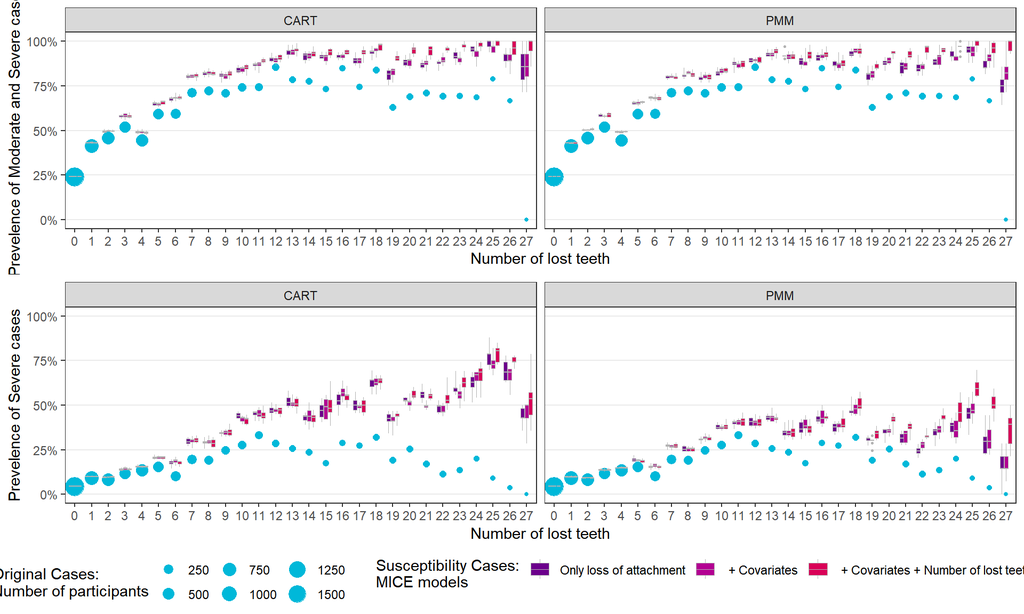

```r
tempfun <- function(var){
  #rely on the variables in the .Global
  #return a figure
  #only include pmm, cart
  d_df %>%
    group_by(df) %>% count(num_missing_tooth, !!as.name(var)) %>%
    pivot_wider(names_from = !!as.name(var), values_from = n) %>%
    mutate(df = str_remove_all(df, pattern = "(^HPC//d_)|(^d_)|(_\\d.d$)|(_\\d\\d.d$)")) %>%
    filter(df %in% c("orgin", "miced_pmm_OHX", "miced_pmm_OHX_demo_Q4_smk",
                     "miced_pmm_OHX_demo_Q4_smk_numtooth",
                     "miced_cart_OHX", "miced_cart_OHX_demo_Q4_smk",
                     "miced_cart_OHX_demo_Q4_smk_numtooth")) %>%
    replace_na(list(`FALSE` = 0, `TRUE` = 0)) %>%
    mutate(method = str_extract(df, "(pmm)|(cart)|(orgin)")) %>%
    mutate(method = if_else(method == "orgin",
                            list(list("pmm", "cart")),
                            sapply(method, as.list, simplify = FALSE))) %>%
    unnest_longer(col = method) %>%
    mutate(model = str_remove_all(df, pattern = "(miced_cart_)|(miced_pmm_)")) %>%
    mutate(prev = `TRUE`/(`FALSE` + `TRUE`)) %>%
    mutate(sample_size = `FALSE` + `TRUE`) %>%
    mutate(num_missing_tooth = as.factor(num_missing_tooth)) %>%
    mutate(method = if_else(method == "pmm", "PMM",
                    if_else(method == "cart", "CART",
                    method))) %>%
    ggplot(aes(x = num_missing_tooth, y = prev), data = .) +
    geom_point(aes(size = sample_size), inherit.aes = TRUE, color = COLORS[2],
               data = . %>% filter(df == "orgin")) +
    scale_size(name = "Original Cases:\nNumber of participants",
               breaks = seq(250, 1500, by=250))+
    #guides(size=guide_legend(title="Original Data:\nNumber of participants"))+
    geom_boxplot(aes(fill = model), # ymax = max(prev), ymin = min(prev)
                 inherit.aes = TRUE, color = "grey70",
                 linewidth = 0.2, coef = 10, outlier.size = 0.5,
                 data = . %>% filter(df != "orgin")) +
    scale_fill_manual(values = hsv(h=c(336-50, 336-25, 336)/360, s = 1,
                                   v = c(0.55, 0.7, 0.85)),
                      name = "Susceptibility Cases:\nMICE models",
                      labels = c("Only loss of attachment",
                                 " + Covariates",
                                 " + Covariates + Number of lost teeth"))+
    facet_grid(.~method) + theme_bw() +
    theme(panel.grid.major.x = element_blank(),
          panel.grid.minor.y = element_blank())+
    xlab("Number of lost teeth") +
    scale_y_continuous(name = ifelse(var == "S", "Prevelence of Severe cases",
                                     "Prevelence of Moderate and Severe cases"),
                       limits = c(0,1),
                       labels = scales::percent_format(accuracy = 1))
}
fig_temp1 <- tempfun("MS")
fig_temp2 <- tempfun("S")
fig.temp <- lemon::grid_arrange_shared_legend(fig_temp1, fig_temp2, ncol=1,
                                              nrow=2, position = "bottom", plot = TRUE)
```

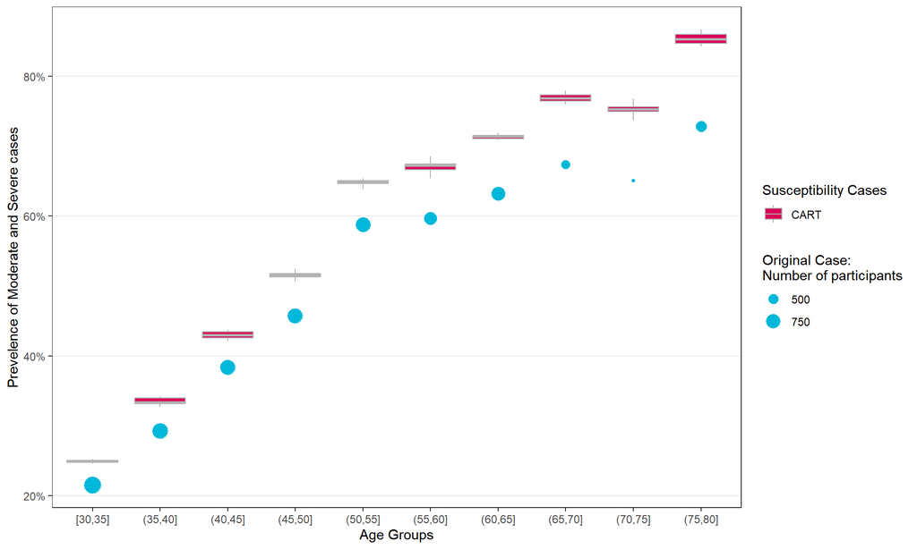

```r
ggsave("figures//Prevelence_missing_models.jpeg", fig.temp,
       width = FIG.WIDTH*1.5, height = 1*FIG.WIDTH, dpi = 1000)
ggsave("figures//Prevelence_missing_models.pdf", fig.temp,
       width = FIG.WIDTH*1.5, height = 1*FIG.WIDTH)

tempfun2 <- function(var){
  #rely on the variables in the .Global
  #return a figure
  #only include pmm and cart!!!!!
  d_df %>%
    mutate(age_grp = cut(age, seq(30, 80, by=5), include.lowest = TRUE)) %>%
    group_by(df) %>% count(age_grp, !!as.name(var)) %>%
    pivot_wider(names_from = !!as.name(var), values_from = n) %>%
    mutate(df = str_remove_all(df, pattern = "(^HPC//d_)|(^d_)|(_\\d.d$)|(_\\d\\d.d$)")) %>%
    filter(df %in% c("orgin",
                     "miced_cart_OHX_demo_Q4_smk_numtooth")) %>%
    replace_na(list(`FALSE` = 0, `TRUE` = 0)) %>%
    mutate(method = str_extract(df, "(pmm)|(cart)|(orgin)")) %>%
    mutate(model = str_remove_all(df, pattern = "(miced_cart_)|(miced_pmm_)")) %>%
    mutate(prev = `TRUE`/(`FALSE` + `TRUE`)) %>%
    mutate(sample_size = `FALSE` + `TRUE`) %>%
    ggplot(aes(x = age_grp, y = prev), data = .) +
    geom_point(aes(size = sample_size), inherit.aes = TRUE, color = COLORS[2],
               data = . %>% filter(df == "orgin")) +
    scale_size(name = "Original Case:\nNumber of participants",
               breaks = seq(250, 1500, by=250))+
    geom_boxplot(aes(fill = model), # ymax = max(prev), ymin = min(prev)
                 inherit.aes = TRUE, color = "grey70",
                 linewidth = 0.5, coef = 10, outlier.size = 0.5,
                 data = . %>% filter(df != "orgin")) +
    scale_fill_manual(values = COLORS[1],
                      name = "Susceptibility Cases",
                      labels = c("CART"))+
    # facet_grid(method~.) +
    theme_bw() +
    theme(panel.grid.major.x = element_blank(),
          panel.grid.minor.y = element_blank())+
    xlab("Age Groups") +
    ylab(ifelse(var == "S", "Prevelence of Severe cases",
                "Prevelence of Moderate and Severe cases"))+
    scale_y_continuous(labels = scales::percent_format(accuracy = 1))#+
    # ylim(0,1)
}
fig_temp1 <- tempfun2("MS")
fig_temp2 <- tempfun2("S")
fig_temp1
```

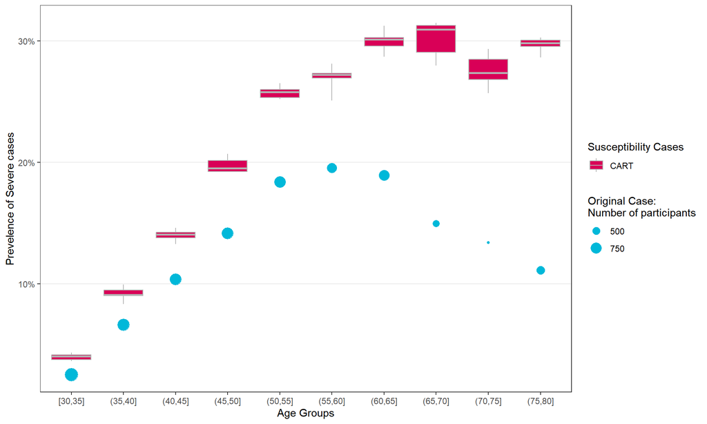

```r
ggsave("figures//Prevelence_MS_age.jpeg", fig_temp1,
       width = FIG.WIDTH, height = 0.75*FIG.WIDTH, dpi = 1000)
ggsave("figures//Prevelence_MS_age.pdf", fig_temp1,
       width = FIG.WIDTH, height = 0.75*FIG.WIDTH)
fig_temp2
```

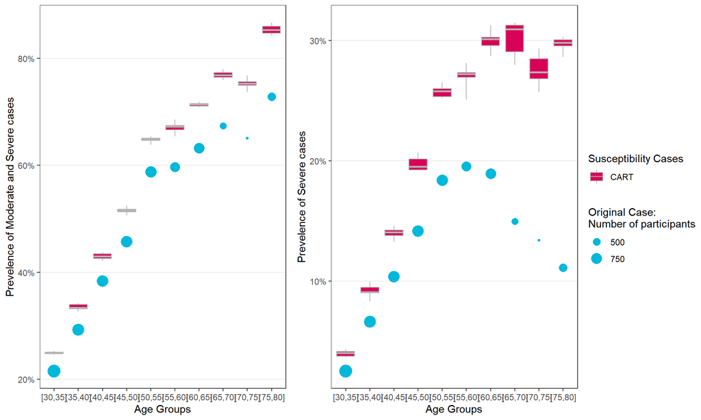

```r
ggsave("figures//Prevelence_Severe_age.jpeg", fig_temp2,
       width = FIG.WIDTH, height = 0.75*FIG.WIDTH, dpi = 1000)
ggsave("figures//Prevelence_Severe_age.pdf", fig_temp2,
       width = FIG.WIDTH, height = 0.75*FIG.WIDTH)
fig.temp <- lemon::grid_arrange_shared_legend(fig_temp1, fig_temp2,
                                              ncol=2, position = "right", plot = TRUE)
```

```r
ggsave("figures//Prevelence_age.jpeg", fig.temp,
       width = FIG.WIDTH*2, height = 0.75*FIG.WIDTH, dpi = 1000)
ggsave("figures//Prevelence_age.pdf", fig.temp,
       width = FIG.WIDTH*2, height = 0.75*FIG.WIDTH)
```

# 8 Comparing case definitions between MICEd dataset and oringinal dataset

```r
tempfun <- function(d){
  #this function returns a summary table (kable) of ps, MS and S
  summary(d[,c("ps","MS","S")]) %>%
    kbl(caption = "Number of periodontal diseases in the MICEd dataset") %>%
    kable_classic(full_width = F, html_font = "Cambria")
}

tempfun2 <- function(d_orgin, d_miced){
  #compare frequecies between miced and original dataset
  #only input a single data frame
  #return a comparison table with original definition in columns
  d_miced_ps <- d_miced %>% select(seqn, ps)
  d_orgin_ps <- d_orgin %>% select(seqn, ps)

  comparison <- full_join(d_miced_ps, d_orgin_ps, by = "seqn")
  comparison$ps.x <- factor(comparison$ps.x,
                            levels = c("no", "mild","mod","sev"))
  comparison$ps.y <- factor(comparison$ps.y,
                            levels = c("no", "mild","mod","sev"))
  comparison_tbl <- with(comparison,table(ps.y, ps.x))
  comparison_tbl <- cbind(comparison_tbl, "Original" = rowSums(comparison_tbl))
  comparison_tbl <- rbind(comparison_tbl, "Imputed" = colSums(comparison_tbl))
  return(comparison_tbl)
}

models = str_replace("HPC//d_miced_cart_OHX_demo_Q4_numtooth_NUM.d",
                     "NUM", as.character(1:10))
temp <- array(data = NA, dim = c(5,5,length(models)),
              dimnames = list(c("no", "mild","mod","sev", "Imputed"),
                              c("no", "mild","mod","sev", "Original"),
                              NULL))
for(i in 1:length(models)){
  temp[ , ,i] <- tempfun2(d_orgin = d_orgin,
                          d_miced = d_list[[models[i]]])
}
comparison_mean <- round(apply(temp, MARGIN = c(1,2), FUN = mean))
comparison_sd <- round(apply(temp, MARGIN = c(1,2), FUN = sd))
comparison_tbl <- matrix(paste(c(comparison_mean),
                               if_else(c(comparison_sd) == 0, "",
                                       paste(" \U00B1 ", c(comparison_sd), sep = "")),
                               sep = ""),
                    nrow = 5, ncol=5, byrow = FALSE)
comparison_tbl[, 5] <- paste(comparison_tbl[, 5], " (",
                             round(comparison_mean[,5]/comparison_mean[5,5]*100,
                                   digits = 1),
                             "%)", sep ="")
comparison_tbl[5, 1:4] <- paste(comparison_tbl[5, 1:4], "\n(",
                             round(comparison_mean[5, 1:4]/comparison_mean[5,5]*100,
                                   digits = 1), " \U00B1 ",
                             round(comparison_sd[5, 1:4]  /comparison_mean[5,5]*100,
                                   digits = 1), "%)",
                             sep ="")
colnames(comparison_tbl) <- c("Healthy", "Mild", "Moderate", "Severe", "Total original cases")
rownames(comparison_tbl) <- c("Healthy", "Mild", "Moderate", "Severe", "Total susceptibility cases")

tbl.temp <- comparison_tbl%>%
  kbl("html", escape = F) %>%
  kable_classic(full_width = F, html_font = "Cambria")
tbl.temp
```

|  | Healthy | Mild | Moderate | Severe | Total original cases |
| --- | --- | --- | --- | --- | --- |
| Healthy | 2727 ± 11 | 50 ± 8 | 355 ± 7 | 30 ± 4 | 3163 (45.1%) |
| Mild | 0 | 372 ± 4 | 70 ± 4 | 7 ± 2 | 449 (6.4%) |
| Moderate | 0 | 0 | 2048 ± 14 | 479 ± 14 | 2527 (36.1%) |
| Severe | 0 | 0 | 0 | 867 | 867 (12.4%) |
| Total susceptibility cases | 2727 ± 11 (38.9 ± 0.2%) | 422 ± 8 (6 ± 0.1%) | 2473 ± 19 (35.3 ± 0.3%) | 1384 ± 16 (19.8 ± 0.2%) | 7006 (100%) |

```r
save_kable(tbl.temp, file = "figures//Case_Definition_comparison.jpeg",
           density = 1000, zoom = 2.5)
```

# 9 Distribution of dental measurements of Ramfjord teeth pre- and post-imputation

Using “cart” method and OHX+covariates+num.missing.tooth model.

```r
Ramfjord <- names(d_orgin) %>% str_subset(pattern = "^ohx(03)|(09)|(12)|(19)|(25)|(28)")
Full_mouth <- names(d_orgin) %>% str_subset(pattern = "^ohx")

temp_fun <- function(d){
  #count the number of specific LA/PC measurements at Ramfjord teeth
  d <- d %>% select(all_of(Ramfjord)) %>% #the order of select = the order of Ramfjord
    apply(MARGIN = 2, FUN = table, useNA = "no") %>% bind_rows() %>%
    as.matrix() %>% reshape2::melt(value.name = "Count", na.rm = FALSE) %>%
    as_tibble() %>%
    rename(Value = "Var2", Teeth = "Var1") %>%
    mutate(Teeth = rep(Ramfjord, max(Value)+1)) %>%
    mutate(tooth = str_extract(Teeth, "\\d\\d"),
           test = str_extract(Teeth, "pc|la"),
           site = str_extract(Teeth, "[d|s|p|a]$")) %>%
    mutate(Count = replace_na(Count, 0))
  return(d)
}

models = str_replace("HPC//d_miced_cart_OHX_demo_Q4_numtooth_NUM.d",
                     "NUM", as.character(1:10))
temp_orgin <- d_list[["d_orgin"]] %>% temp_fun()
temp_miced <- d_list[models] %>%
  lapply(., FUN = temp_fun) %>%
  lapply(., FUN = function(d) return(d$Count - temp_orgin$Count)) %>%
  as.data.frame() %>%
  mutate(Recovered = apply(., MARGIN = 1, FUN = mean),
         SD = apply(., MARGIN = 1, FUN = sd)) %>%
  select(Recovered, SD) %>%
  cbind(temp_orgin, .) %>%
  as_tibble() %>%
  rename(Observed = "Count") %>%
  mutate(tooth =
    if_else(tooth == "03", "UR First Molar", # "03 UR First Molar",
    if_else(tooth == "09", "UL Central Incisor", #"09 UL Central Incisor",
    if_else(tooth == "12", "UL First Premolar",#"12 UL First Premolar",
    if_else(tooth == "19", "LL First Molar",#"19 LL First Molar",
    if_else(tooth == "25", "LR Central Incisor",#"25 LR Central Incisor",
    if_else(tooth == "28", "LR First Premolar", #"28 LR First Premolar",
            tooth))))))) %>%
  mutate(site =
           if_else(site == "d", "DF",
                   if_else(site == "s", "MF",
                           if_else(site == "p", "DL",
                                   if_else(site == "a", "ML", site)))))

measurement = "la"
temp <- temp_miced %>%
  filter(test == measurement) %>%
  pivot_longer(cols = c("Observed", "Recovered"),
               names_to = "Type", values_to = "Count") %>%
  mutate(SD = if_else(Type == "Observed", true = NA_real_, false = SD))
temp2 <- temp %>% group_by(Teeth, Value) %>%
  dplyr::summarise(tooth = unique(tooth), test = unique(test), site = unique(site),
                   SD = sum(SD, na.rm = TRUE), Count = sum(Count)) %>%
  ungroup()
```

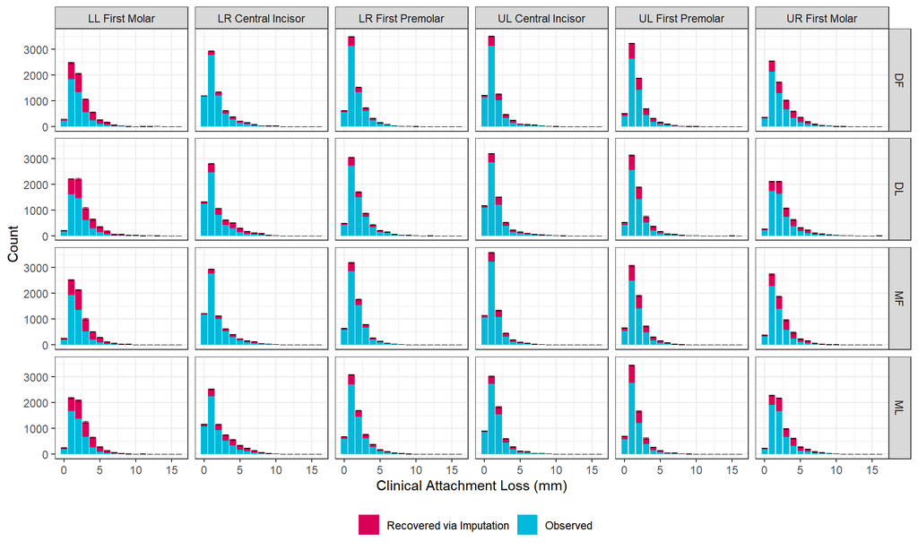

```r
fig.temp <- temp %>%
  ggplot(aes(x= Value, y = Count,
             fill = factor(Type, levels=c("Recovered", "Observed")))) +
  geom_bar(stat="identity", position = "stack") + facet_grid(site~tooth) +
  geom_errorbar(mapping = aes(ymin = Count-SD, ymax = Count+SD, x = Value), width=0.8,
                position=position_dodge(.9), data = temp2, inherit.aes = FALSE,
                color = "black", linewidth = 0.1)+
  xlab(ifelse(measurement == "la", "Clinical Attachment Loss (mm)", "Pocket Depth (mm)")) +
  scale_fill_manual(name = element_blank(), values = COLORS[c(1,2)],
                    labels = c("Recovered via Imputation", "Observed")) +
  theme_bw() + theme(legend.position="bottom")
fig.temp
```

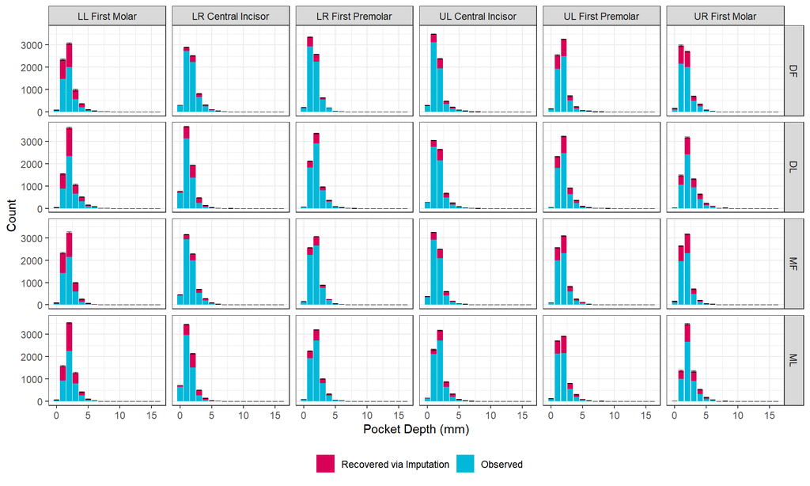

```r
ggsave(paste("figures//Recovered ", measurement, ".jpeg", sep = ""),
       fig.temp, width = FIG.WIDTH*1, height = 0.625*FIG.WIDTH, dpi = 1000)
ggsave(paste("figures//Recovered ", measurement, ".pdf", sep = ""),
       fig.temp, width = FIG.WIDTH*1, height = 0.625*FIG.WIDTH)

measurement = "pc"
temp <- temp_miced %>%
  filter(test == measurement) %>%
  pivot_longer(cols = c("Observed", "Recovered"),
               names_to = "Type", values_to = "Count") %>%
  mutate(SD = if_else(Type == "Observed", true = NA_real_, false = SD))
temp2 <- temp %>% group_by(Teeth, Value) %>%
  dplyr::summarise(tooth = unique(tooth), test = unique(test), site = unique(site),
                   SD = sum(SD, na.rm = TRUE), Count = sum(Count)) %>%
  ungroup()
fig.temp <- temp %>%
  ggplot(aes(x= Value, y = Count,
             fill = factor(Type, levels=c("Recovered", "Observed")))) +
  geom_bar(stat="identity", position = "stack") + facet_grid(site~tooth) +
  geom_errorbar(mapping = aes(ymin = Count-SD, ymax = Count+SD, x = Value), width=0.8,
                position=position_dodge(.9), data = temp2, inherit.aes = FALSE,
                color = "black", linewidth = 0.1)+
  xlab(ifelse(measurement == "la", "Clinical Attachment Loss (mm)", "Pocket Depth (mm)")) +
  scale_fill_manual(name = element_blank(), values = COLORS[c(1,2)],
                    labels = c("Recovered via Imputation", "Observed")) +
  theme_bw() + theme(legend.position="bottom")
fig.temp
```

```r
ggsave(paste("figures//Recovered ", measurement, ".jpeg", sep = ""),
       fig.temp, width = FIG.WIDTH*1, height = 0.625*FIG.WIDTH, dpi = 1000)
ggsave(paste("figures//Recovered ", measurement, ".pdf", sep = ""),
       fig.temp, width = FIG.WIDTH*1, height = 0.625*FIG.WIDTH)

if(RECYCLE)
  rm(list = c("temp_orgin", "temp_miced", "temp_fun"))
```

# 10 Spatial correlation of original and imputed dental measurements

Based on a 1% random sample stratified on number of lost teeth.

```r
# set.seed(seed=12314)
d_miced <- d_list[["HPC//d_miced_cart_OHX_demo_Q4_smk_numtooth_1.d"]]
OHX_col <- str_detect(names(d_miced), pattern = "^ohx")
d_miced_array <- array(NA, dim = c(dim(d_orgin)[1], sum(OHX_col), 10),
                       dimnames = NULL)
for(i in 1:10){
  d_miced_array[,,i] <-
    as.matrix(d_list[[str_glue("HPC//d_miced_cart_OHX_demo_Q4_smk_numtooth_{i}.d")]][,OHX_col])
}
d_miced_ohx <- apply(d_miced_array, MARGIN = c(1,2), FUN = mean)
d_miced[, OHX_col] <- d_miced_ohx
d_miced_plot <- d_miced %>%
  group_by(num_missing_tooth) %>%
  slice_sample(prop = 0.01) %>%
  ungroup()
dist_mds <- d_miced_plot %>% select(starts_with("ohx")) %>%
  as.matrix() %>% dist() %>% cmdscale(., eig=TRUE, k=1)
seqn_order <- as.character(d_miced_plot$seqn[order(dist_mds$points)])


d_miced_plot_CAL <- d_miced_plot%>%
  select(seqn,
         starts_with("ohx") & ends_with(str_c("la", c("d", "s", "p", "a")))) %>%
  pivot_longer(cols = starts_with("ohx"),
               names_to = "site_id",
               values_to = "value")
d_orgin_plot_CAL <- d_orgin %>%
  filter(seqn %in% d_miced_plot$seqn) %>%
  select(seqn,
         starts_with("ohx") & ends_with(str_c("la", c("d", "s", "p", "a")))) %>%
  pivot_longer(cols = starts_with("ohx"),
               names_to = "site_id",
               values_to = "value")
d_plot <- left_join(d_miced_plot_CAL, d_orgin_plot_CAL, by = c("seqn", "site_id")) %>%
  mutate(value.x = if_else(is.na(value.y), value.x, NA)) %>%
  mutate(site_id = str_remove(site_id, pattern = "^ohx"))%>%
  mutate(site_id = str_replace(site_id, pattern = "(pc)|(la)", "  ")) %>%
  # rename("isimputed" = "value.y") %>%
  mutate(seqn = as.factor(seqn)) %>%
  mutate(seqn = fct_relevel(seqn, seqn_order))
head(d_plot)
```

```
## # A tibble: 6 × 4
##   seqn  site_id value.x value.y
##   <fct> <chr>     <dbl>   <int>
## 1 63528 02  d        NA       1
## 2 63528 02  s        NA       2
## 3 63528 02  p        NA       2
## 4 63528 02  a        NA       2
## 5 63528 03  d        NA       2
## 6 63528 03  s        NA       2
```

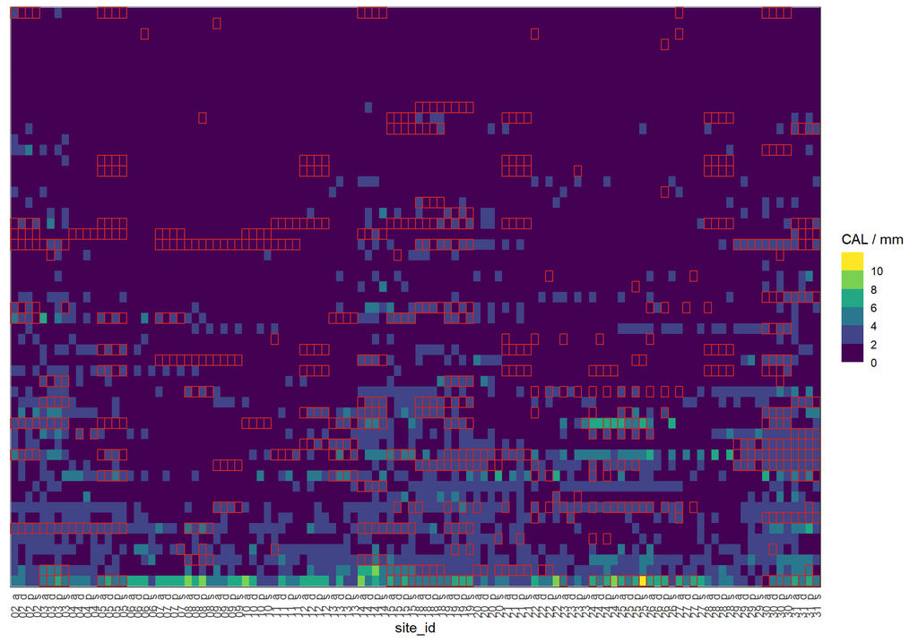

```r
CAL <- ggplot(d_plot, aes(x = site_id, y = seqn)) +
  geom_tile(data = subset(d_plot, !is.na(value.y)), aes(fill = value.y)) +
  geom_tile(data = subset(d_plot, !is.na(value.x)), aes(fill = value.x),
            color = "firebrick3", linewidth = 0.5) +
  scale_color_manual(values = "firebrick3", na.value = NA, guide = NULL) +
  scale_fill_viridis_b(breaks = c(0,2,4,6,8,10,12), name = "CAL / mm") +
  theme_bw() +
  theme(axis.text.x = element_text(angle = 90, vjust = 0.5, hjust=1),
        axis.ticks.x=element_blank(), #remove x axis ticks
        axis.text.y=element_blank(),  #remove y axis labels
        axis.ticks.y=element_blank(),
        axis.title.y= element_blank())
CAL
```

```r
d_miced_plot_PD <- d_miced_plot%>%
  select(seqn,
         starts_with("ohx") & ends_with(str_c("pc", c("d", "s", "p", "a")))) %>%
  pivot_longer(cols = starts_with("ohx"),
               names_to = "site_id",
               values_to = "value")
d_orgin_plot_PD <- d_orgin %>%
  filter(seqn %in% d_miced_plot$seqn) %>%
  select(seqn,
         starts_with("ohx") & ends_with(str_c("pc", c("d", "s", "p", "a")))) %>%
  pivot_longer(cols = starts_with("ohx"),
               names_to = "site_id",
               values_to = "value")
d_plot <- left_join(d_miced_plot_PD, d_orgin_plot_PD, by = c("seqn", "site_id")) %>%
  mutate(value.x = if_else(is.na(value.y), value.x, NA)) %>%
  mutate(site_id = str_remove(site_id, pattern = "^ohx"))%>%
  mutate(site_id = str_replace(site_id, pattern = "(pc)|(la)", "  ")) %>%
  # rename("isimputed" = "value.y") %>%
  mutate(seqn = as.factor(seqn)) %>%
  mutate(seqn = fct_relevel(seqn, seqn_order))
head(d_plot)
```

```
## # A tibble: 6 × 4
##   seqn  site_id value.x value.y
##   <fct> <chr>     <dbl>   <int>
## 1 63528 02  d        NA       1
## 2 63528 02  s        NA       2
## 3 63528 02  p        NA       2
## 4 63528 02  a        NA       2
## 5 63528 03  d        NA       2
## 6 63528 03  s        NA       2
```

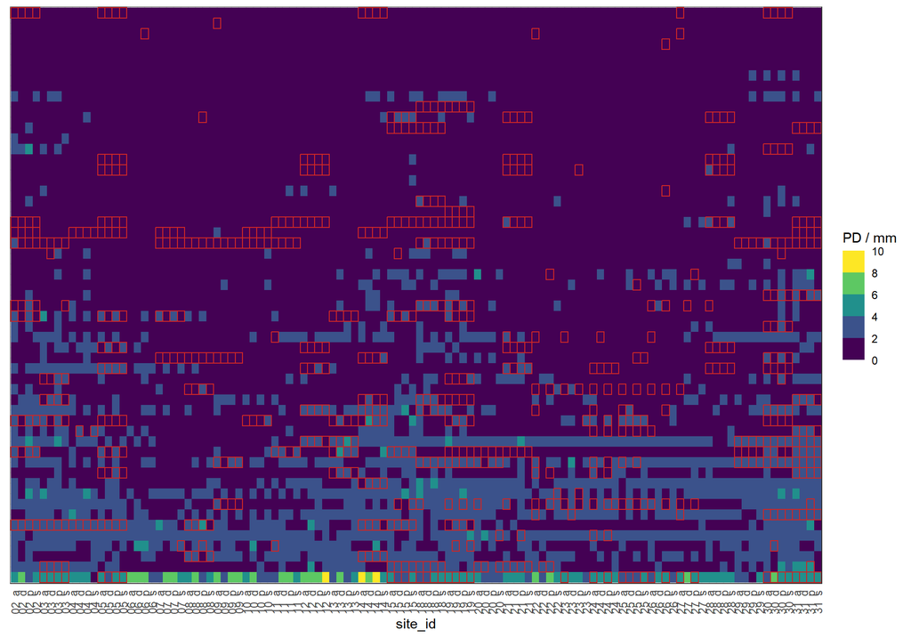

```r
PD <- ggplot(d_plot, aes(x = site_id, y = seqn)) +
  geom_tile(data = subset(d_plot, !is.na(value.y)), aes(fill = value.y)) +
  geom_tile(data = subset(d_plot, !is.na(value.x)), aes(fill = value.x),
            color = "firebrick3", linewidth = 0.5) +
  scale_color_manual(values = "firebrick3", na.value = NA, guide = NULL) +
  scale_fill_viridis_b(breaks = c(0,2,4,6,8,10), name = "PD / mm") +
  theme_bw() +
  theme(axis.text.x = element_text(angle = 90, vjust = 0.5, hjust=1),
        axis.ticks.x=element_blank(), #remove x axis ticks
        axis.text.y=element_blank(),  #remove y axis labels
        axis.ticks.y=element_blank(),
        axis.title.y= element_blank())
PD
```

```r
ggsave("figures//CAL_imputed.jpeg", CAL,
       width = 12, height = 6, dpi = 300)
ggsave("figures//CAL_imputed.pdf", CAL,
       width = 12, height = 6, dpi = 300)
ggsave("figures//PD_imputed.jpeg", PD,
       width = 12, height = 6, dpi = 300)
ggsave("figures//PD_imputed.pdf", PD,
       width = 12, height = 6, dpi = 300)
```

# 11 Model Validation using ATT of smk_stt

- Using `smk_stt` as the covariate to establish the validity of missing data imputation.
- Using propensity score matching method.
  - propensity score model:
    $$logit(SMK) =
    \beta_0 + \beta_1 AGE + \beta_2 SEX + \beta_3 RACE_{BLACK} + \beta_4
    RACE_{HISPANIC} + \beta_5 RACE_{OTHER}$$
- If the method is valid, we expect to have a higher average causal treatment effect among the treated (ATT) (a higher risk of prondental disease) among those who smoke, especially when $ATT = 0$ in the original dataset.

```r
#Propensity models using age, sex, race as the covariates
#smk_stt is not balanced between sex and race
tabUnmatched <- tableone::CreateTableOne(strata = "smk_stt", data = d_orgin,
                                         vars = c("age","sex","race"),test = FALSE)
tableone::kableone(tabUnmatched, smd = TRUE) %>%
  kable_classic(full_width = F, html_font = "Cambria")
```

|  | FALSE | TRUE | SMD |
| --- | --- | --- | --- |
| n | 3919 | 3087 |  |
| age (mean (SD)) | 51.24 (14.32) | 52.87 (14.18) | 0.115 |
| sex = male (%) | 1617 (41.3) | 1874 (60.7) | 0.397 |
| race (%) |  |  | 0.254 |
| black | 843 (21.5) | 662 (21.4) |  |
| hispanic | 1078 (27.5) | 667 (21.6) |  |
| other | 508 (13.0) | 250 ( 8.1) |  |
| white | 1490 (38.0) | 1508 (48.9) |  |

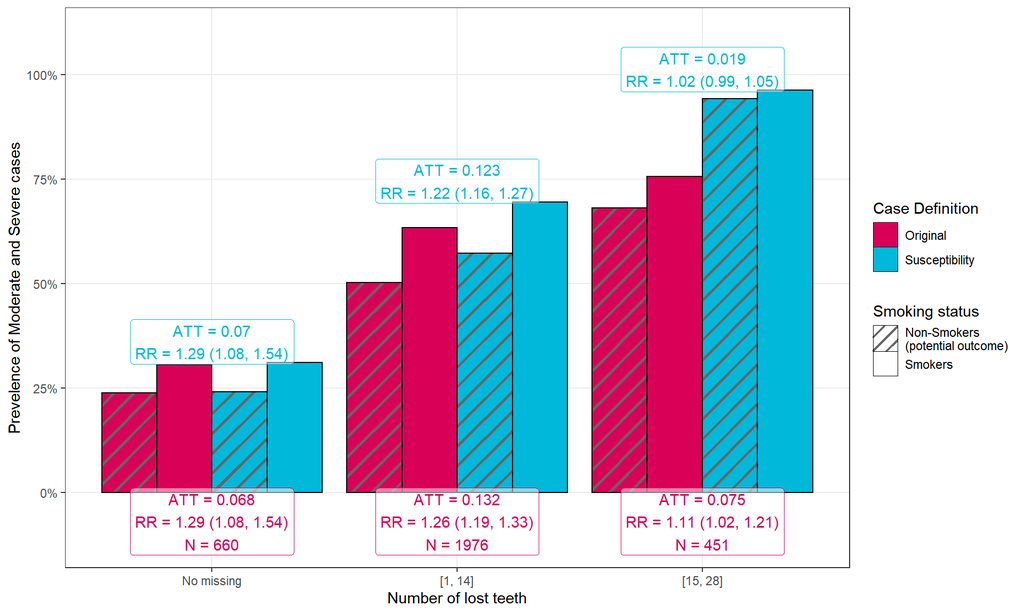

```r
tempfun2 <- function(d, var = "S"){
  #calculate the ATT of smk_stt on prodentitist using propensity score matching
  #within approach: do the PS matching in each imputed dataset
  rownames(d) <- 1:nrow(d)
  d <- d %>% mutate(sex = as.factor(sex), race = as.factor(race))
  mod_match <- MatchIt::matchit(smk_stt ~ age + sex + race,
                                data = d, ratio = 1, replace = TRUE)
  match_index <- as.numeric(mod_match$match.matrix)

  d_var <- dplyr::pull(d, var)
  x1 <- sum(d_var[d$smk_stt == TRUE])
  x0 <- sum(d_var[match_index])

  n1 <- sum(d$smk_stt == TRUE)
  n0 <- length(match_index)
  p1 <- x1/n1
  p0 <- x0/n0
  RR <- p1/p0
  CI_RR <- exp(log(RR) + c(-1, 1)*qnorm(0.975)*sqrt(1/x1 + 1/x0 - 1/n1 - 1/n0))
  ATT <- p1 -  p0
  SE_ATT <- sqrt(p1*(1-p1)/n1 + p0*(1-p0)/n0)
  CI_ATT <- p1 - p0 + c(-1, 1)*qnorm(0.975)*SE_ATT
  return(list(ATT = ATT, CI = CI_ATT, p1=p1, p0=p0, N = n1, RR = RR, CI_RR = CI_RR, N0= n0))
}

tempfun3 <- function(seg, d, var = "S"){
  #this function calculate ATT/the aesthetics required for one dataset
  x = seg[1]
  xend = seg[2]
  d.seg <- d %>% dplyr::filter(num_missing_tooth >= x & num_missing_tooth < xend)
  d.seg.ATT <- tempfun2(d.seg, var = var)
  result <- data.frame(x=rep(x,2), xend=rep(xend,2),
                       y=c(d.seg.ATT$p0, d.seg.ATT$p1),
                       yend=c(d.seg.ATT$p0, d.seg.ATT$p1),
                       trt = c("Non-Smokers", "Smokers"),
                       RR = c(NA_character_,
                              paste(round(d.seg.ATT$RR, digits = 2), " (",
                                    paste(round(d.seg.ATT$CI_RR,digits = 2), collapse = ", "),
                                    ")", sep = "")),
                       Nt = c(d.seg.ATT$N0, d.seg.ATT$N)
                       )
  return(result)
}

tempfun4 <- function(d_list, var = "S", typical = 1,
                     segment = data.frame(x = c(0, 0.8, 14.8),
                                          xend = c(0.2, 14.2, 28.2))
                     ){
  #this function calculate ATT/the aesthetics required for all datasets
  d_list_ATT <- lapply(d_list,
                       FUN = function(x) apply(segment, MARGIN = 1,
                                               FUN = tempfun3, d = x, var = var) ) %>%
    lapply(., bind_rows) %>%
    bind_rows(.id = "df")
  d_list_ATT %>%
    mutate(source = str_extract(df, pattern = "(miced)|(orgin)"),
           typical = str_detect(df, pattern = paste("(orgin)|", typical, sep=""))) %>%
    mutate(typical = as.factor(typical)) #%>%
}

tempfun5 <- function(d, var = "S"){
  #this function calculate prevalence/the aesthetics required for one dataset
  d_prev <- d %>%
    count(num_missing_tooth, !!as.name(var)) %>%
    pivot_wider(names_from = !!as.name(var), values_from = n) %>%
    replace_na(list(`FALSE` = 0, `TRUE` = 0)) %>%
    mutate(prev = `TRUE`/(`FALSE` + `TRUE`)) %>%
    mutate(sample_size = `FALSE` + `TRUE`)
  return(d_prev)
}
tempfun6 <- function(d_list, var = "S", typical = 1){
  #this function calculate prevalence/the aesthetics required for all datasets
  d_list %>% lapply(., FUN = tempfun5, var = var) %>%
    bind_rows(.id = "df") %>%
    mutate(source = str_extract(df, pattern = "(miced)|(orgin)"),
           typical = str_detect(df, pattern = paste("(orgin)|", typical, sep=""))) %>%
    mutate(typical = as.factor(typical))
}


tempfun7 <- function(var, TYPICAL, d_list){
  #just a wrapper function to plot the ATT figure
  #return a figure
  #for tempfun2-6, it's OK to process multiple miced datasets
  #because the results are not pooled, but in this function
  #miced data are averaged!!
  d_list_ATT <- d_list %>%
    tempfun4(d_list = ., var = var, typical = TYPICAL,
             segment = data.frame(x = c(0, 0.8, 14.8),
                                  xend = c(0.2, 14.2, 28.2))) %>%
    mutate(source = if_else(source=="orgin", true = "Original", source)) %>%
    mutate(source = if_else(source=="miced", true = "Imputed", source)) %>%
    group_by(source, trt, x) %>%
    summarise(x= unique(x), xend = unique(xend),
              Nt = mean(Nt, na.rm = TRUE),
              y = mean(y), yend = mean(yend)) %>%
    ungroup()
  d_list_RR_CI <- d_list_ATT %>%
    pivot_wider(id_cols = c("source","x", "xend", "Nt"),
                names_from = trt, values_from = y) %>%
    mutate(RR = `Smokers`/`Non-Smokers`,
           x0 = `Non-Smokers`*Nt, x1 = `Smokers`*Nt,
           n0 = Nt, n1 = Nt,
           CI_low = exp(log(RR) + (-1)*qnorm(0.975)*sqrt(1/x1 + 1/x0 - 1/n1 - 1/n0)),
           CI_high = exp(log(RR) + (+1)*qnorm(0.975)*sqrt(1/x1 + 1/x0 - 1/n1 - 1/n0))
    )
  d_list_RR_CI <- d_list_RR_CI %>%
    mutate(notes = paste(
      "ATT = ", round(`Smokers`-`Non-Smokers`, digits = 3),"\n",
      "RR = ", round(RR, digits = 2),
      # if_else(source == "Imputed","",
      if_else(rep(FALSE,6),"",
              paste(" (", round(CI_low, digits = 2), ", ",
                    round(CI_high, digits = 2), ")", sep = "")),
      if_else(source == "Imputed", "", paste("\nN = ", Nt, sep = "")),
      sep = "")
    ) %>%
    mutate(subgroup = paste("[", ceil(x), ", ", floor(xend), "]", sep = "")) %>%
    mutate(subgroup = factor(subgroup)) %>%
    mutate(subgroup = fct_recode(subgroup, `No missing` = "[0, 0]" )) %>%
    mutate(source = factor(source)) %>%
    mutate(source = fct_rev(source)) %>%
    mutate(y = if_else(source == "Imputed", `Smokers` + 0.05, NA_real_)) %>%
    mutate(y = if_else(source == "Original", 0        - 0.07, y       ))%>%
    select(source, subgroup, y, Nt, RR, notes)

  d_list_ATT %>% mutate(subgroup = paste("[", ceil(x), ", ", floor(xend), "]", sep = "")) %>%
    mutate(subgroup = factor(subgroup)) %>%
    mutate(subgroup = fct_recode(subgroup, `No missing` = "[0, 0]" )) %>%
    mutate(source = factor(source)) %>%
    mutate(source = fct_rev(source)) %>%
    mutate(source = fct_recode(source, Susceptibility="Imputed")) %>%
    ggplot(aes(x = subgroup, fill = source, y = y, pattern = trt)) +
    geom_bar_pattern(stat="identity", position = "dodge", color = "black",
                     pattern_fill = "grey40", pattern_colour = "grey40",
                     pattern_angle = 45,
                     pattern_density = 0.1,
                     pattern_spacing = 0.025,
                     pattern_key_scale_factor = 0.6)+
    geom_label(aes(x=subgroup, y=y, label = notes, color = source),
               data = d_list_RR_CI, alpha = 0.5, inherit.aes = FALSE) +
    scale_color_manual(values = COLORS[c(1,2)],
                       guide = "none") +
    scale_pattern_manual(values = c(`Non-Smokers` = "stripe", `Smokers` = "none"),
                         name = "Smoking status",
                         labels = c("Non-Smokers\n(potential outcome)",
                                    "Smokers"))+
    scale_fill_manual(values = COLORS[c(1,2)],
                       name = "Case Definition") +
    scale_x_discrete(name = "Number of lost teeth")+
    scale_y_continuous(name = ifelse(var == "S", "Prevelence of Severe cases",
                                     "Prevelence of Moderate and Severe cases"),
                       breaks = (if(var == "S") c(0, 0.25, 0.5, 0.75) else
                         c(0, 0.25, 0.5, 0.75, 1)),
                       limits = c(-0.12, ifelse(var == "S", 0.75, 1.1)),
                       labels = scales::percent_format(accuracy = 1))+
    theme_bw()+
    theme(panel.grid.minor.x = element_blank(),
          panel.grid.minor.y = element_blank())+
    guides(pattern = guide_legend(override.aes = list(fill = "white")),
           fill = guide_legend(override.aes = list(pattern = "none"))) -> fig.temp
  return(fig.temp)
}
TYPICAL = 2
models = c("d_orgin",
           str_replace("HPC//d_miced_cart_OHX_demo_Q4_numtooth_NUM.d",
                       "NUM", as.character(1:10)))
fig.temp1 <- tempfun7(var = "MS", TYPICAL = 2, d_list = d_list[models])
fig.temp1
```

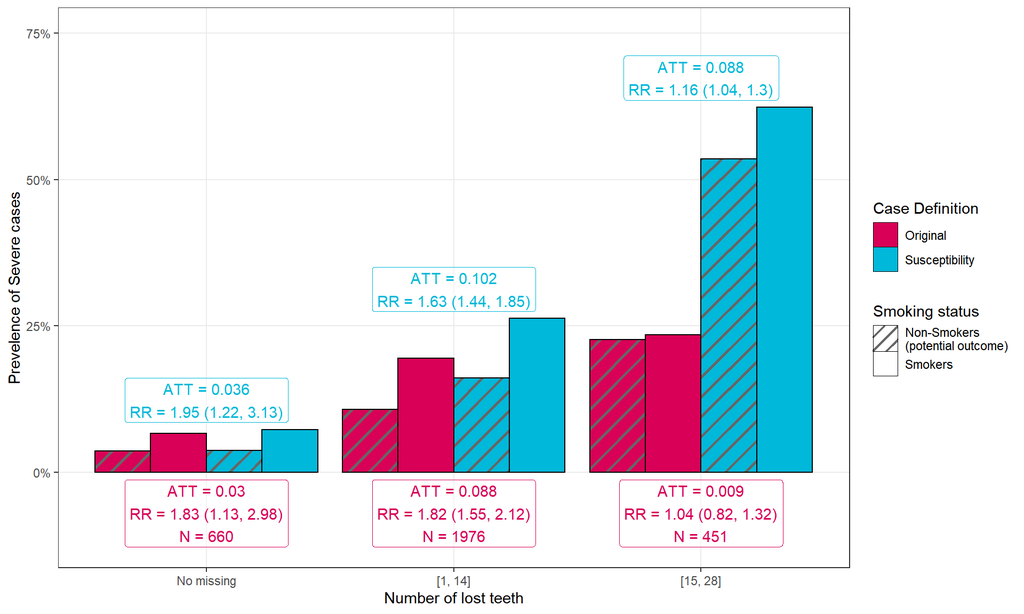

```r
ggsave("figures//ATT of smk (outcome moderate severe).jpeg", fig.temp1,
       width = FIG.WIDTH, height = 0.75*FIG.WIDTH, dpi = 1000)
ggsave("figures//ATT of smk (outcome moderate severe).pdf", fig.temp1,
       width = FIG.WIDTH, height = 0.75*FIG.WIDTH, dpi = 1000)
fig.temp2 <- tempfun7(var = "S", TYPICAL = 2, d_list = d_list[models])
fig.temp2
```

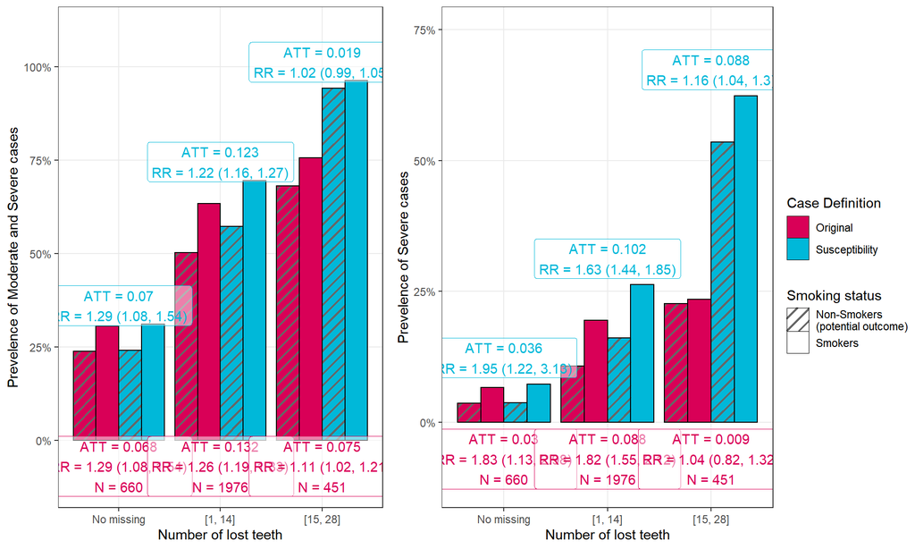

```r
ggsave("figures//ATT of smk (outcome severe).jpeg", fig.temp2,
       width = FIG.WIDTH, height = 0.75*FIG.WIDTH, dpi = 1000)
ggsave("figures//ATT of smk (outcome severe).pdf", fig.temp2,
       width = FIG.WIDTH, height = 0.75*FIG.WIDTH, dpi = 1000)
fig.temp <- lemon::grid_arrange_shared_legend(fig.temp1, fig.temp2,
                                              ncol=2, position = "right", plot = TRUE)
```

```r
ggsave("figures//ATT of smk.jpeg", fig.temp,
       width = FIG.WIDTH*1.75, height = 0.75*FIG.WIDTH, dpi = 1000)
ggsave("figures//ATT of smk.pdf", fig.temp,
       width = FIG.WIDTH*1.75, height = 0.75*FIG.WIDTH, dpi = 1000)
```